# 09_explicabilidad_modelos

#### Nombre: **09_explicabilidad_modelos**

#### Autores: *Sergio Cañón Laiz y Ignacio Ruiz de Zuazu Echavarría*

#### 15/01/2021

```python
import os
import matplotlib.pyplot as plt
from keras.preprocessing import image
import numpy as np
from keras.models import load_model
from keras.preprocessing import image
from keras.applications.vgg16 import preprocess_input, decode_predictions
import numpy as np
import cv2
from keras import models

import tensorflow as tf
from keras import backend as K
```

# Introducción

Se dice que los modelos de aprendizaje profundo son "black box": representaciones de aprendizaje que son difíciles de extraer y se presentan en una forma legible por humanos.

Sin embargo, Las representaciones aprendidas por convnets son muy fáciles de visualizar, en gran parte porque son representaciones de conceptos visuales. Hay varias técncias como:

- Visualización de salidas intermedias
- Visualización de mapas de calor de activación de clases en una imagen

## Visualización de salidas intermedias

Consiste en mostrar las características de salida por varias capas de convolución y agrupación en una CNN. Esto da una idea de cómo se descompone una entrada en los diferentes filtros aprendidos por la CNN.

```python
# importamos el modelo

model_face = load_model('../models/model_sgd_age_rgb.h')
model_face.summary()
```

```
Model: "sequential"
_________________________________________________________________
Layer (type)                 Output Shape              Param #
=================================================================
conv2d (Conv2D)              (None, 32, 32, 256)       3328
_________________________________________________________________
max_pooling2d (MaxPooling2D) (None, 16, 16, 256)       0
_________________________________________________________________
dropout (Dropout)            (None, 16, 16, 256)       0
_________________________________________________________________
dense (Dense)                (None, 16, 16, 128)       32896
_________________________________________________________________
conv2d_1 (Conv2D)            (None, 16, 16, 50)        25650
_________________________________________________________________
max_pooling2d_1 (MaxPooling2 (None, 8, 8, 50)          0
_________________________________________________________________
dropout_1 (Dropout)          (None, 8, 8, 50)          0
_________________________________________________________________
flatten (Flatten)            (None, 3200)              0
_________________________________________________________________
dense_1 (Dense)              (None, 256)               819456
_________________________________________________________________
dropout_2 (Dropout)          (None, 256)               0
_________________________________________________________________
dense_2 (Dense)              (None, 5)                 1285
=================================================================
Total params: 882,615
Trainable params: 882,615
Non-trainable params: 0
_________________________________________________________________
```

```python
# A continuación, metemos una imagen que no forma parte de las imágenes de la redfue entrenado en

img_path = '../data/04_autores/ignacio.jpg'

#Preprocesa la imagen en un tensor 4D

img = image.load_img(img_path, target_size=(32, 32)) #modelo entrenado en 32x32
img_tensor = image.img_to_array(img) # imagen a array
img_tensor = np.expand_dims(img_tensor, axis=0)
img_tensor /= 255. # normalizamos
print(img_tensor.shape) # forma
```

```
(1, 32, 32, 3)
```

[figure not shown]

```python
# mostramos la imagen

plt.imshow(img_tensor[0])
plt.show()
```

```python
# extraemos los outputs de cada capa
layer_outputs = [layer.output for layer in model_face.layers]

# creamos un modelo que devolverá el output de cada capa
activation_model = models.Model(inputs=model_face.input, outputs=layer_outputs)

# devuelve una lista de arrays. Un array por cada capa
activations = activation_model.predict(img_tensor)

# ejemplo de la forma de la primera activación
# 32x32 con 256 canales
first_layer_activation = activations[0]
print(first_layer_activation.shape)
```

```
(1, 32, 32, 256)
```

```python
# nombre de las capas para ponerlas en las imagenes

layer_names = []
for layer in model_face.layers:
    layer_names.append(layer.name)

# nombres

layer_names
```

```
['conv2d',
 'max_pooling2d',
 'dropout',
 'dense',
 'conv2d_1',
 'max_pooling2d_1',
 'dropout_1',
 'flatten',
 'dense_1',
 'dropout_2',
 'dense_2']
```

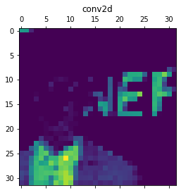

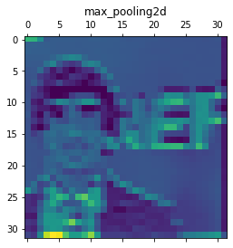

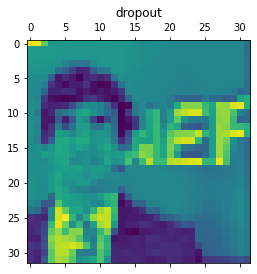

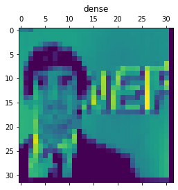

[figure not shown]

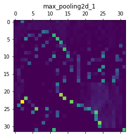

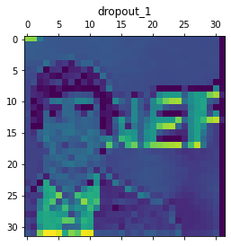

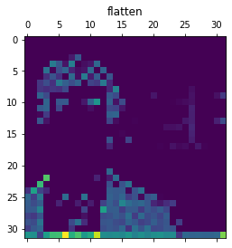

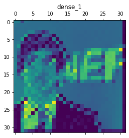

```python
#para cada capa, mostaramos su imagen output

for i in range(9):
    plt.matshow(first_layer_activation[0, :, :, i], cmap='viridis')
    plt.title(layer_names[i])
```

La primera capa actúa como una colección de varios detectores de formas. En esa etapa, las activaciones retienen casi toda la información presente en la imagen inicial. En este caso a detectado: el cuerpo y las letras de CUNEF.

## Visualizing heatmaps of class activation

Esta técnica es útil para entender qué partes de una imagen determinada llevaron a un convnet a su decisión de clasificación final, y para depurar el proceso de decisión de un convnet, particularmente en el caso de un error de clasificación. También te permite localizar objetos específicos en una imagen.

```python
#importamos imagen
img_path = '../data/04_autores/sergio.jpg'

#prepocesado

img = image.load_img(img_path, target_size=(32, 32)) # resize
x = image.img_to_array(img) # imagen a array


#Agrega una dimensión para transformar la matriz en un tamaño (1, 32, 32, 3)
x = np.expand_dims(x, axis=0)
x = preprocess_input(x) # normalización
```

```python
preds = model_face.predict(x) #predicion con el modelo

#el vector de predicción que se activó al máximo es el 0

np.argmax(preds[0])
```

```
0
```

```python
sergio_output = model_face.output[:, 0]
```

```python
# salida del conv2d. Primera convolution

last_conv_layer = model_face.get_layer('conv2d')
```

```python
tf.compat.v1.disable_eager_execution()
```

```python
grads = K.gradients(sergio_output, last_conv_layer.output)[0]

pooled_grads = K.mean(grads, axis=(0, 1, 2))

iterate = K.function([model_face.input],
                     [pooled_grads, last_conv_layer.output[0]])

# canales en el feature-map. Se multiplica por la importacia de la clasificacion
for i in range(256):
    conv_layer_output_value[:, :, i] *= pooled_grads_value[i]

 # media  del resultado de cada clase de activación
heatmap = np.mean(conv_layer_output_value, axis=-1)
```

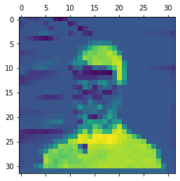

```python
heatmap_2 = np.maximum(heatmap, 0)
heatmap_3 = np.max(heatmap)/heatmap_2
plt.matshow(heatmap)
```

```python
# carga el imagen original

img = cv2.imread(img_path)

heatmap_4 = cv2.resize(heatmap_3, (img.shape[1], img.shape[0]))

# convierte el heatmap en RGB
heatmap_5 = np.uint8(255 * heatmap_4)

# aplicamos el heatmap a la imagen original
heatmap_6 = cv2.applyColorMap(heatmap_5, cv2.COLORMAP_JET)

# factor de intensidad
superimposed_img = heatmap_6 * 0.4 + img
```

```python
cv2.imwrite('../data/04_autores/sergio_02.jpg', superimposed_img)
```

```
True
```

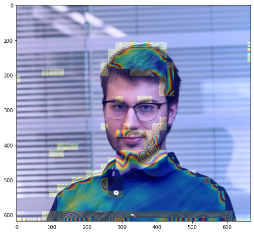

```python
img = image.load_img('../data/04_autores/sergio_02.jpg')
# mostramos la imagen
plt.figure(figsize=(10,8))

plt.imshow(img)
plt.show()
```

En la imagen de calor, se ve los puntos en los que se más se activan las capas. Por alguna razón se activan más en el pelo y en en el polo.

Realmente, haría falta mejores recursos computacionales para procesar más imágenes y más grandes. Para una CNN, la diferencia entre en un género o raza, está en detalles muy pequeños que necesita procesar con bastante capacidad computacional.